# CLT

# Central Limit Theorem

We’ve seen several times that a sampling distribution of the mean of a sample from any distribution is normal.

If we take a sample of size $n$:
$$X_1, X_2, X_3, \dots, X_n$$
from a distribution with mean $\mu$ and standard deviation $\sigma$, the sampling distribution of $\overline{X}$ is approximately normal with mean $\mu$ and standard deviation $\frac{\sigma}{\sqrt{n}}$.

*Assumptions:*

- $n$ is *sufficiently* large
- The $X_i$ are independent
- The $X_i$ come from the same distribution

This provides another way to generate a distribution against which to compare an observed statistic and ask whether the observation is sufficiently unlikely to conclude that it is significant.

## Example

Suppose I know that the average marathon time in 2019 was 240 minutes and times had a standard deviation of 30 minutes. What is the probability that a randomly selected group of 6 marathon runners have an average time of no more than 180 minutes? We want to compute
$$P(\overline{T} \leq 180).$$
The sampling distribution of $\overline{T}$ is approximately normal with mean 240 and standard deviation $\frac{30}{\sqrt{6}}$. We answer the question with:

```r
pnorm(180, mean=240, sd=30/sqrt(6))
```

```
## [1] 4.816785e-07
```

This answer is the area under the curve below to the left of 180.

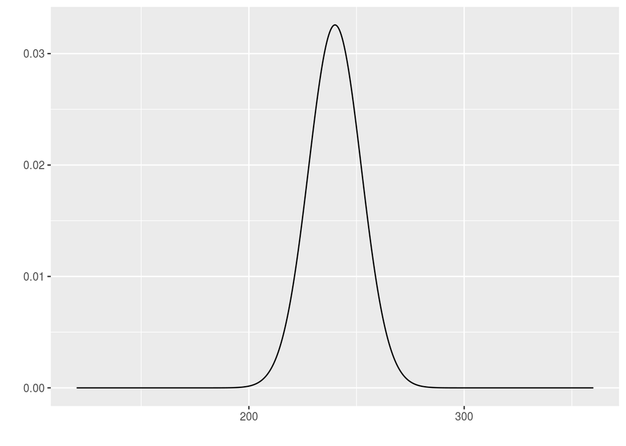

```r
library(ggfortify)
ggdistribution(dnorm, seq(120, 360, 0.1), mean=240, sd=30/sqrt(6))
```

# Application of CLT to binomial random variables.

## Example

17% of people in Colorado have received the vaccine against coronavirus. In a room of 60 people what is the probability that between 5 and 10 people have been vaccinated?

The thing to notice here is that a normal distribution is continuous while a binomial distribution is discrete.

It is common practice however to apply the CLT to this situation if $np$ and $n(p-1)$ are both large, say greater than 10.

In this case, the *proportion* (not mean) is approximately normally distributed with a mean of $p$ and a standard deviation of $\sqrt{\frac{p(1-p)}{n}}$. Here $p$ is the probability of success.

First, we check the *sufficiently large* conditions:

```r
p<-.17
n=60
n*p
```

```
## [1] 10.2
```

```r
n*(1-p)
```

```
## [1] 49.8
```

Both are larger than 10, so we proceed.

(The book also provides the mean and standard deviation for counts, you just have to make sure everything is consistent - counts or proportions, but not a mix.)

We’ll answer the question by finding the area under the pdf of normal distribution with mean $\mu=p$ and standard deviation $\sigma=\sqrt{\frac{p\cdot (1-p)}{n}}$.

```r
n<-60
p<-0.17
mu<-p
sigma<-sqrt(p*(1-p)/n)
pnorm(10/n, mean=mu, sd=sigma)-pnorm(5/n, mean=mu, sd=sigma)
```

```
## [1] 0.4356439
```

The following is the discrete distribution. Imagine the continuous normal distribution superimposed. The continuous approximation, perhaps, doesn’t compute the *right* area.

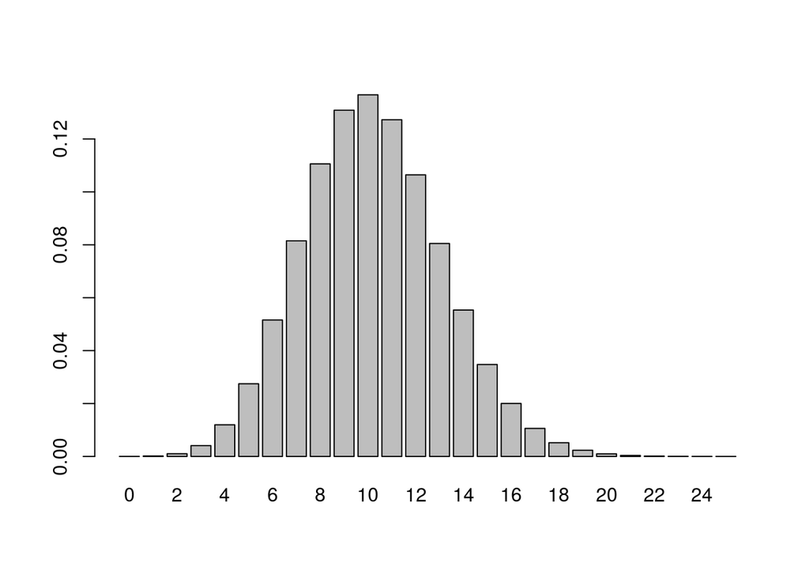

```r
barplot(dbinom(0:25, 60,p),names.arg=0:25)
```

```r
pnorm(10.5/n, mean=mu, sd=sigma)-pnorm(4.5/n, mean=mu, sd=sigma)
```

```
## [1] 0.5160044
```

The authors make an interesting comment about this technique of estimating a binomial distribution with a normal distribution via the central limit theorem:

“For binomial data, the common rule of thumb is to use the CLT, with continuity correction, if both $np \geq 10$ and $n(1-p)\geq 10$. This rule is wishful thinking, dating to a precomputer age when one had few realistic alternatives to using the CLT because most other methods were computationally infeasible. We can obtain better approximations using simulation-based methods, including permutation test and bootstrapping. … And for binomial distributions we can do exact calculations.”

Here is the exact calculation:

```r
pbinom(10, 60, p)-pbinom(4, 60, p)
```

```
## [1] 0.5386518
```